# Actividad física y nutrición de los estudiantes de la UTEC durante la pandemia por covid-19 en el ciclo académico 2021.1

## VIII.II. Prueba de hipótesis sobre la relación del sexo con el IMC

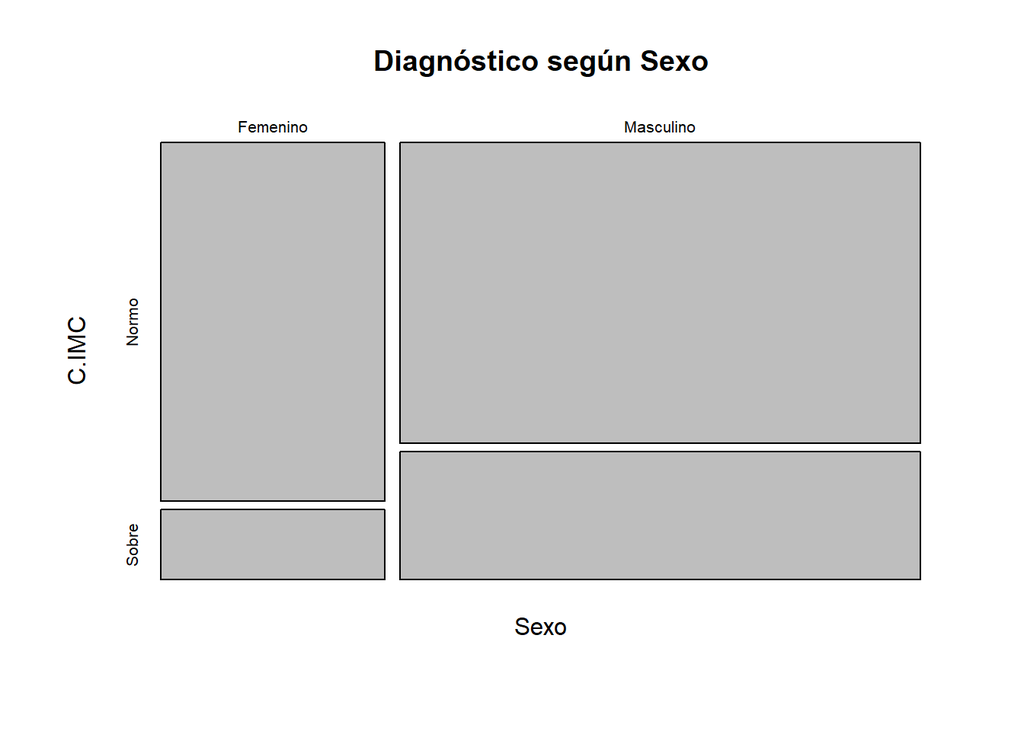

```r
IMC.segun("Sexo")
```

Se intenta determinar si el sexo de la persona está relacionado con el IMC. Por ello, se plantea la siguiente **hipótesis nula: el sexo de un estudiante de la UTEC y su diagnóstico según IMC son variables independientes.** Por lo tanto, se espera que la proporción de cada sexo (masculino/femenino) en cada categoría del IMC (normopeso/sobrepeso) guarde una relación similar con la distribución general del sexo (esto mide la prueba **chi-cuadrado**).

**H0:** **P(Mujer| Normopeso) == P(Mujer) ^** **P(Mujer| Sobrepeso) == P(Mujer) ^** **P(Hombre| Normopeso) == P(Hombre) ^** **P(Hombre| Sobrepeso) == P(Hombre)**

**H1:** **P(Mujer| Normopeso) != P(Mujer) ∨** **P(Mujer| Sobrepeso) != P(Mujer) ∨** **P(Hombre| Normopeso) != P(Hombre) ∨** **P(Hombre| Sobrepeso) != P(Hombre)**

**Importante: notese el ^/∨ (and/or)**

Con el fin de rechazar la hipótesis, se desea saber si la probabilidad de obtener la composición actual de la muestra es lo suficientemente baja. En este caso, se busca un 10% de significancia; se prefiere que la hipótesis nula sea rechazada cuando es cierta **(Error tipo 1)**, pues se trata de un tema sensible (la salud de los estudiantes).

```r
chisq.test(table(select(df, Sexo, C.IMC)))$p.value
```

```
## [1] 0.1070805
```

Como se puede observar, el p-valor obtenido denota una probabilidad que no cumple con el mínimo (no es menor a 10%). No obstante, es importante resaltar que se queda fuera por poco (~0.7%) y que si otro estudio fuera más flexible con este intervalo, podría considerarse evidencia suficiente. Aún así, bajo el 10% establecido, **los datos no son prueba para rechazar la hipótesis nula**. El sexo y el IMC en UTEC **podrían** ser dependientes, pero esto no lo demuestra.

## VIII.III. Prueba de hipótesis sobre la relación de ir al gimnasio o club con el IMC

Se intenta determinar si asistir a un club o gimnasio a ejercitarse **no** está relacionado con el IMC. Por ello, se plantea la siguiente **hipótesis nula: la asistencia al gimnasio o club de un alumno de la UTEC y su IMC son variables dependientes**.

A pesar de tener indicios para sospechar aquello (igual porcentaje de sobrepeso en ambos grupos), lamentablemente, los datos y métodos que manejamos actualmente no nos permite probar independencia, solo dependencia. **En otras palabras, que una prueba no demuestre dependencia, no implica que otra prueba no lo pueda hacer.**

Lo mencionamos porque resulta una hipótesis interesante de probar y que tiene implicancias curiosas; los gimnasios o clubs podrían estar sobrevalorados como métodos para bajar de peso, por lo menos en la UTEC.

## VIII.IV. Prueba de hipótesis sobre la relación de las horas de sedentarismo a la semana con el IMC

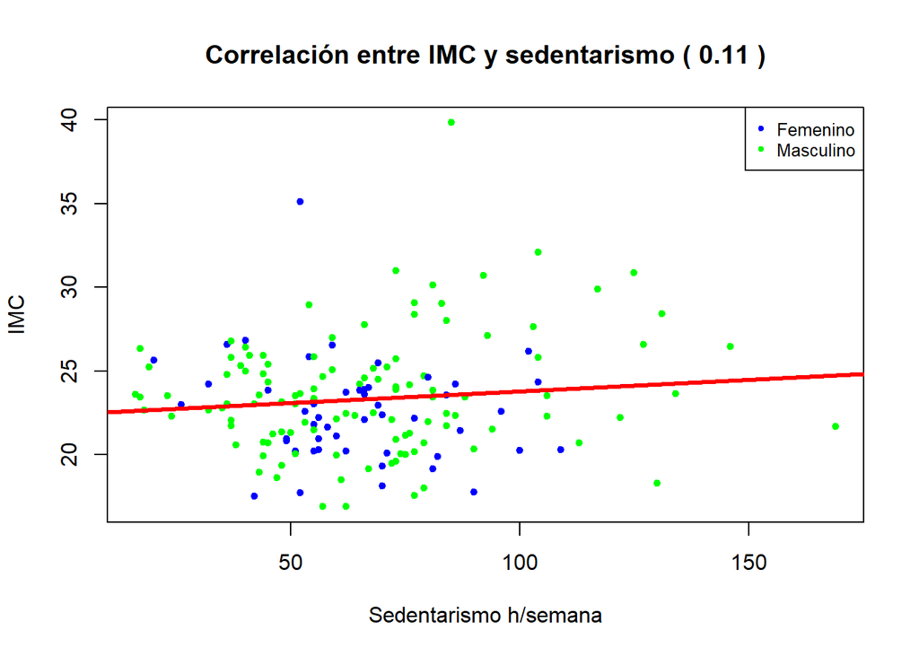

```r
dispersionc("Correlación entre IMC y sedentarismo", "Sedentarismo h/semana", "IMC", df$Sedentarismo, df$IMC, df$Sexo)
```

**(Para no ocupar tanto espacio, las gráficas de diagnósticos no se volvieron a poner. La lectura de estas gráficas está en la sección previa.)**

Se intenta determinar si la cantidad de horas de sedentarismo a la semana guarda una relación lineal con el IMC. Por ello, se se plantea la siguiente **hipótesis nula: las horas de sedentarismo a la semana de un estudiante de la UTEC y su IMC no están relacionadas linealmente.**

Con el fin de rechazar la hipótesis, se busca rechazar otras dos hipótesis. Primero, se intenta contradecir que la pendiente de la recta del sedentarismo y el IMC es 0. Segundo, se intenta contradecir que la recta no explica ninguna porción de los casos. Si alguna de estas no cumple, no hay evidencia suficiente para rechazar la hipótesis inicial.

Para la pendiente: **H0: m == 0**

**H1: m != 0**

Para el F estadístico: **H0: mx + b == b**

**H1: mx + b != b**

En este caso, se busca un 10% de significancia; se prefiere que la hipótesis nula sea rechazada cuando es cierta **(Error tipo 1)**, pues se trata de un tema sensible: la salud de los estudiantes en un escenario sin precedentes, la cuarentena de año y medio.

```r
IMC.Seden = summary(lm(df$IMC ~ df$Sedentarismo))
round(cbind(
  "Intercepto" = IMC.Seden$coefficients[1,1],
  "P-valor" = IMC.Seden$coefficients[1,4]
  ),3)
```

```
##      Intercepto P-valor
## [1,]      22.39       0
```

```r
round(cbind(
  "Pendiente" = IMC.Seden$coefficients[2,1],
  "P-valor" = IMC.Seden$coefficients[2,4]
  ),3)
```

```
##      Pendiente P-valor
## [1,]     0.014    0.17
```

Como se puede observar, el p-valor obtenido denota una probabilidad que no cumple con el mínimo (no es menor a 10%). Por lo tanto, no se puede rechazar la hipótesis sobre la pendiente igual a 0 y, por lo consiguiente, **no se puede rechazar la hipótesis nula** sobre la no relación entre el IMC y el sedentarismo. Puede que el IMC y el sedentarismo en UTEC sí estén relacionados, pero esto no lo prueba.

# VIV. Aproximación del IMC: función alternativa

En este trabajo se ha encontrado distribuciones interesantes sobre las variables relacionadas con ejercicio, sedentarismo y nutrición. Algunas se asemejan a modelos normales y otras a exponenciales, pero todas revelan que se está lejos de la situación ideal: **los estudiantes de la UTEC, en su mayoría, no se ejercitan, ni comen frutas, ni verduras; más bien, invierten la mayor parte de su día en un estado sedentario, gran parte debido las horas de clase y redes sociales.** En otras palabras, este estudio logró recopilar información muy pertinente acerca de los estudiantes y logró resumirla y describirla de manera efectiva para resaltar estos fenómenos.

Lamentablemente, el otro objetivo culminó de una manera indeseable; ninguna de las más de veinte variables, ni 1 ~ 1 (boxplot, mosaico, r. lineal simple), ni 1 ~ N (r. lineal múltiple), demostró explicar el IMC de manera significativa. Es decir, el diagnóstico de obesidad que se pensaba realizar, terminó inconcluso. Esta falta de correlación entre las variables, no obstante, es también **información valiosa: ninguna de estas variables es lo suficientemente influyentes en el IMC.**

Por esto, la investigación propone, para culminar, predecir el IMC en base al peso y otras variables del estudio. Si bien el peso se utiliza para calcular el IMC, también se requiere de la estatura. Entonces, dado que no se tiene la estatura, ¿existirá una forma de aproximar el IMC para los estudiantes de la UTEC?

## VIV.I. Aproximación del IMC con las variables peso y sexo

Después de analizar varias combinaciones, la única variable que notoriamente incrementa la capacidad predictiva es el sexo. A continuación, se puede ver el análisis descriptivo con las gráficas de los residuos, seguido de la pruebas de hipótesis y la fórmula resultante de la regresión múltiple.

En primer lugar, para asegurar que el modelo cumpla con un mínimo de representatividad, se visualizan la gráficas de diagnóstico acerca de los residuos. La gráfica número uno indica que, aparentemente, los residuos no siguen un patrón no lineal. La segunda gráfica indica que los residuos siguen una distribución, casi a totalidad, normal. La tercera gráfica indica que se cumple, en cierta medida, homoestacidad entre los residuos; es decir, la varianza permanece igual (los puntos están dispersos de manera igualitaria en el espacio). La cuarta gráfica indica la existencia de valores que no siguen la tendencia de la mayoría y que modifican considerablemente la recta; en este escenario, solo existe un caso que a las justas influye de manera perjudicial (está en el límite de las lineas punteadas rojas, “distancia de Cook”). **En suma, las gráficas no son prueba suficiente para dudar de la linealidad de la relación.**

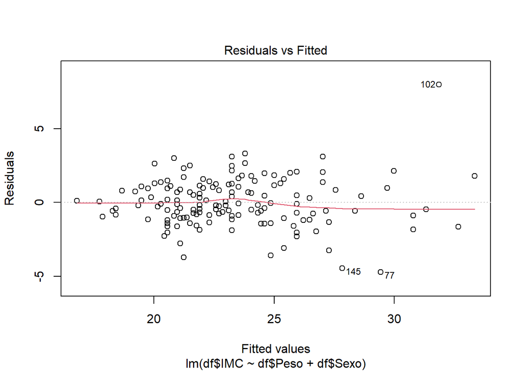

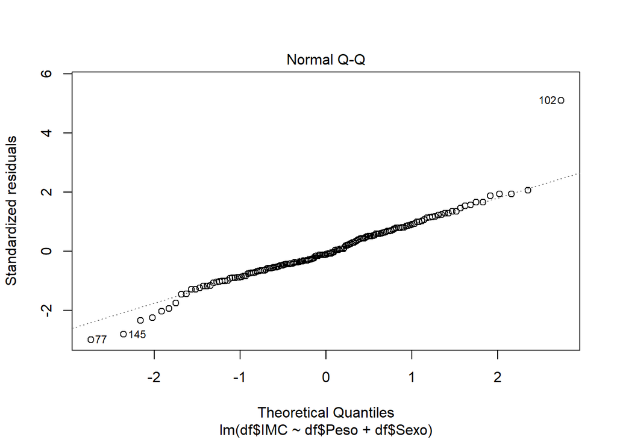

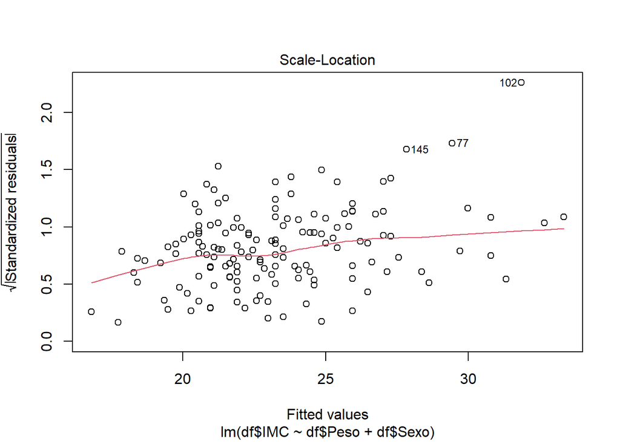

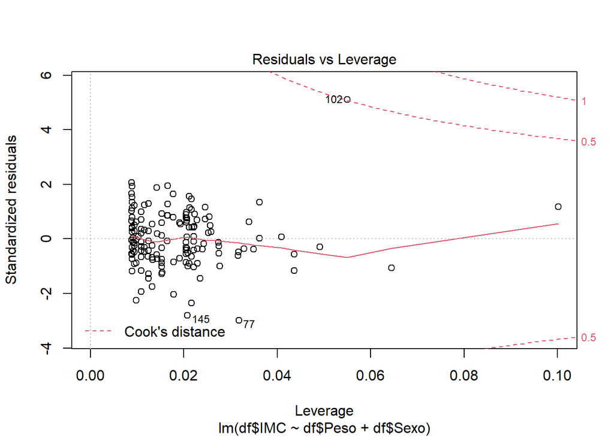

```r
plot(lm(df$IMC ~ df$Peso + df$Sexo))
```

En segundo lugar, una vez confirmado la representatividad de los datos, se realizan las pruebas de hipótesis sobre el modelo predictivo lineal (con una significancia del 10%, por las razones expuestas anteriormente). La primera hipótesis nula que se debe de rechazar es **“intercepto == 0”**. La segunda hipótesis nula que se debe de rechazar es **“pendiente1 == 0” y “pendiente2 == 0”**. La tercera hipótesis nula que se debe de rechazar es **“mx + nz + b == b”**. En estas tres partes, se rechazan las hipótesis nula, pues todos los **p-valores son menores a 0.10**.

```r
summary(lm(df$IMC ~ df$Peso + df$Sexo))
```

```
##
## Call:
## lm(formula = df$IMC ~ df$Peso + df$Sexo)
##
## Residuals:
##     Min      1Q  Median      3Q     Max
## -4.7321 -0.9130 -0.1694  0.9965  7.9761
##
## Coefficients:
##                  Estimate Std. Error t value             Pr(>|t|)
## (Intercept)       6.97378    0.69405  10.048 < 0.0000000000000002 ***
## df$Peso           0.26909    0.01132  23.780 < 0.0000000000000002 ***
## df$SexoMasculino -2.55723    0.31470  -8.126    0.000000000000114 ***
## ---
## Signif. codes:  0 '***' 0.001 '**' 0.01 '*' 0.05 '.' 0.1 ' ' 1
##
## Residual standard error: 1.608 on 160 degrees of freedom
## Multiple R-squared:  0.7842, Adjusted R-squared:  0.7815
## F-statistic: 290.7 on 2 and 160 DF,  p-value: < 0.00000000000000022
```

Ergo, para el 78.15% de los datos, casi 4/5, se explica el IMC con la siguiente fórmula:

**IMC = (0.26909)(Peso) + (-2.55723)(Masculino ? 1 : 0) + 6.97378**

Es decir, si se conoce el peso y el sexo de un estudiante de la UTEC, podemos aproximar su IMC (y su diagnostico de obesidad) con la formula de arriba. A continuación, se muestra unos ejemplos:

```r
imc.aprox = function(peso, masculino) (0.26909)*(peso) + (-2.55723)*(masculino) + 6.97378
writeLines(c(
paste("IMC.APROX(70kg|Masculino):", imc.aprox(70, 1)), # hombre
paste("IMC.APROX(70kg|Femenino):", imc.aprox(70, 0)) # mujer
))
```

```
## IMC.APROX(70kg|Masculino): 23.25285
## IMC.APROX(70kg|Femenino): 25.81008
```

Se puede observar que para un mismo peso (70kg), el IMC del hombre de UTEC obtiene un puntaje de 23.25, mientras que la mujer 25.81. **El primero con peso ideal, el segundo con sobrepeso**. Una explicación razonable podría ser una que demuestre una diferencia considerable entre el tamaño promedio de mujeres y hombres de UTEC (para aumentar la seguridad al máximo, solo acá se escoge 99%).

```r
pm = df$Estatura[df$Sexo == "Masculino"]
pf = df$Estatura[df$Sexo == "Femenino"]
writeLines(c(
paste("Media(Estatura|Hombres):", text.interval(imean(mean(pm), sd(pm), length(pm), 0.99))),
paste("Media(Estatura|Mujeres):", text.interval(imean(mean(pf), sd(pf), length(pf), 0.99)))
))
```

```
## Media(Estatura|Hombres): ( 172.13 , 175.32 )
## Media(Estatura|Mujeres): ( 157.95 , 162.14 )
```

La distancia entre intervalos del 99% de confianza da una idea de la diferencia sustancial en el tamaño habitual de hombres y mujeres en UTEC, y con ello, se explica, en parte, la funcionalidad de la fórmula propuesta. **Es relativamente seguro utilizar esta formula para predecir el IMC de un estudiante de la UTEC**.

De esta manera, con el análisis descriptivo y probabilístico, recapitulado en el comienzo de esta sección, y la construcción de esta fórmula con regresión múltiple, el proyecto de Estadísticas y Probabilidades 2021.1 culmina.

# Bibliografía

1. Nuttall, F. Q. (2015). Body mass index: obesity, BMI, and health: a critical review. Nutrition today, 50(3), 117.
2. World Health Organization. (1995). Physical status: The use of and interpretation of anthropometry, Report of a WHO Expert Committee. World Health Organization.